# Session 1 — Spatial Data and Maps

Vector data · sf · coordinate systems · joins · choropleths · Lab 1

Community Medicine Workshop

## Where we are

- Health data has a **place**: a village, a block, a facility, a patient’s home
- Today: how R stores places, and how to make an **honest map**
- By the end you can:
  - read spatial data and say what an `sf` object is
  - name the **CRS** and **transform** before measuring
  - **join** attributes and **spatially** join points to polygons
  - map **rates, not counts**, with a defensible classification

## Our data: a synthetic district

- **79 blocks** (polygons) with population, poverty, literacy, dengue cases
- **30 health facilities** (points)
- Everything is **invented**: no real boundaries or people
- Built so dengue **clusters** in space: later sessions test that

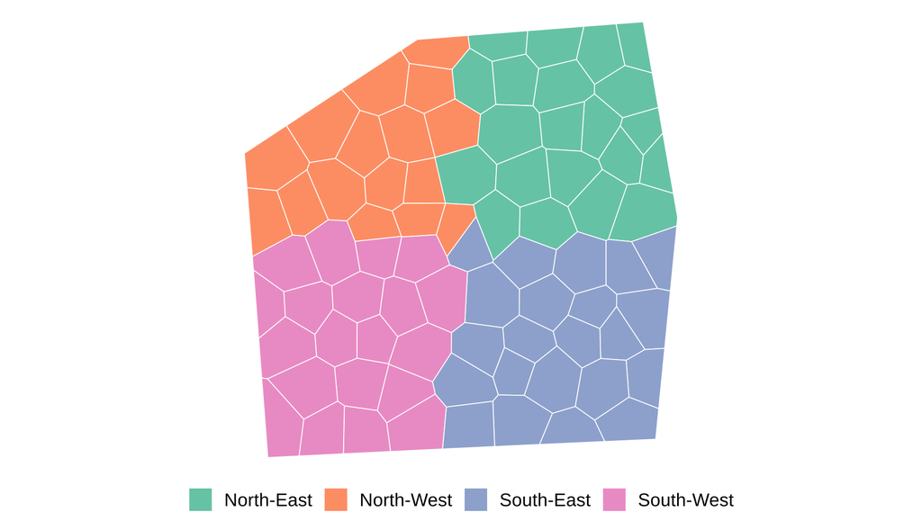

# Topic 1 — Spatial data in R

## Three kinds of vector geometry (plus raster)

| Type | Example | Class |
| --- | --- | --- |
| **Point** | facility, case home | `POINT` |
| **Line** | road, river | `LINESTRING` |
| **Polygon** | block, district | `POLYGON` |
| Raster | population grid, satellite | `terra` / `stars` (not today) |

An **`sf` object is a data frame with one extra column, `geometry`**. Every `dplyr` verb you know still works.

## Reading a layer

```r
class(blocks)
```

```
[1] "sf"         "data.frame"
```

```r
blocks |> st_drop_geometry() |> head(4)
```

```
  block_id block_name   district population poverty_index literacy_pct area_km2
1      B01  Block B01 North-East      29800          34.3         79.5     71.8
2      B02  Block B02 North-East      12900          42.5         83.5     97.7
3      B03  Block B03 North-East      20300          34.2         87.5     65.8
4      B04  Block B04 North-West      32800          25.7         92.3     87.7
  dengue_cases dengue_per_100k high_burden
1           16            53.7    Not high
2            4            31.0    Not high
3           19            93.6        High
4           10            30.5    Not high
```

```r
ggplot(blocks) + geom_sf(fill = "grey95", colour = "grey40") + labs(title = "79 blocks")
```

## Reading a layer

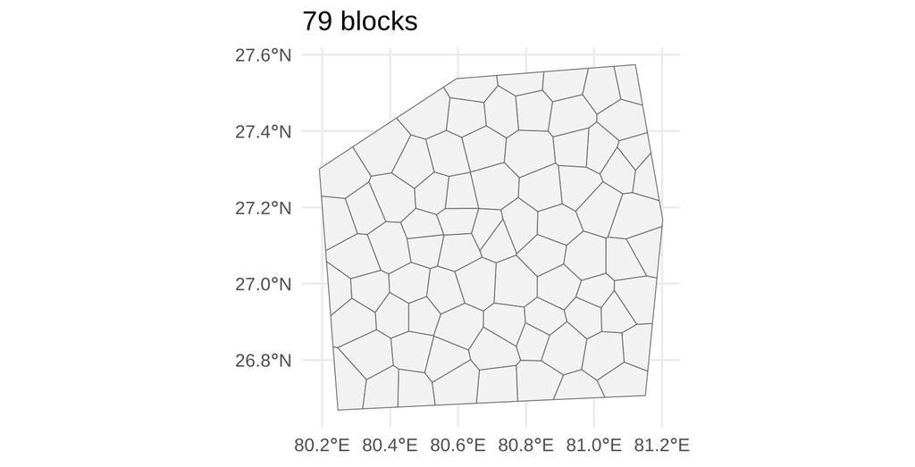

# Topic 2 — Coordinate reference systems

## A CRS says how numbers become places

**Geographic** (e.g. EPSG:**4326**)

- longitude / latitude in **degrees**
- good for storing and web maps
- **wrong for area and distance**

**Projected** (e.g. UTM 44N, EPSG:**32644**)

- **metres**
- good for **area, length, distance, buffers**
- one projection suits one region

```r
st_crs(blocks)$input
```

```
[1] "WGS 84"
```

```r
blocks_utm <- st_transform(blocks, 32644)
st_crs(blocks_utm)$input
```

```
[1] "EPSG:32644"
```

## Why it matters

```r
tibble(block = blocks$block_id[1:3], recorded_km2 = blocks$area_km2[1:3],
       computed_in_metres = round(as.numeric(st_area(blocks_utm))[1:3] / 1e6, 1))
```

```
# A tibble: 3 × 3
  block recorded_km2 computed_in_metres
  <chr>        <dbl>              <dbl>
1 B01           71.8               71.8
2 B02           97.7               97.7
3 B03           65.8               65.8
```

Always check `st_crs()` before measuring. Two layers can only be combined if they share a CRS, so `st_transform()` one to match the other.

# Topic 3 — Joins

## Attribute join and spatial join

```r
fac <- read_csv(fac_path, show_col_types = FALSE) |> st_as_sf(coords = c("easting_m", "northing_m"), crs = 32644)
blocks_utm$n_fac <- lengths(st_intersects(blocks_utm, fac))     # facilities per block
table(blocks_utm$n_fac)
```

```
 0  1  2  3
54 21  3  1
```

- **Attribute join:** `left_join(sf_object, table, by = "key")`: same as ordinary data
- **Spatial join:** `st_join(points, polygons)`: *which polygon is each point in?*
- `st_intersects()` / `st_within()` give TRUE/FALSE per pair; `lengths()` counts them
- `st_distance()` gives distances in the CRS units (**metres** if projected)

## Distance to the nearest facility

```r
cen <- st_centroid(blocks_utm)
blocks_utm$km_to_fac <- apply(st_distance(cen, fac), 1, min) / 1000
ggplot(blocks_utm) + geom_sf(aes(fill = km_to_fac)) + geom_sf(data = fac, colour = "red", size = 1.6) +
  scale_fill_viridis_c(name = "km", direction = -1) + labs(title = "Distance to nearest facility (red = facilities)")
```

## Distance to the nearest facility

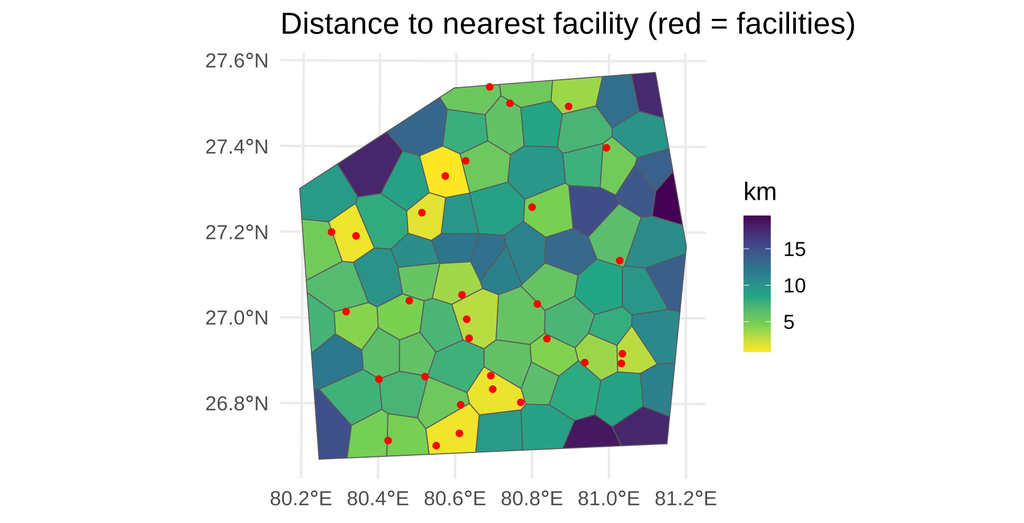

# Topic 4 — Honest choropleths

## Counts mislead, rates do not

```r
p1 <- ggplot(blocks) + geom_sf(aes(fill = dengue_cases)) + scale_fill_viridis_c(name = "Cases") + labs(title = "Counts")
p2 <- ggplot(blocks) + geom_sf(aes(fill = dengue_per_100k)) + scale_fill_viridis_c(name = "per 100,000", option = "magma", direction = -1) + labs(title = "Rate per 100,000")
p1 + p2
```

Counts follow **population size**. Map **rates** for risk; counts only for workload.

## Counts mislead, rates do not

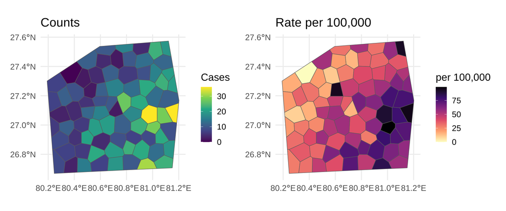

## Classification changes the story

```r
library(classInt)
cls <- function(x, style) cut(x, classIntervals(x, 5, style = style)$brks, include.lowest = TRUE)
bind_rows(mutate(blocks, scheme = "Equal interval", k = cls(dengue_per_100k, "equal")),
          mutate(blocks, scheme = "Quantile", k = cls(dengue_per_100k, "quantile")),
          mutate(blocks, scheme = "Jenks", k = cls(dengue_per_100k, "jenks"))) |>
  ggplot() + geom_sf(aes(fill = k), colour = "white", linewidth = 0.1) + facet_wrap(~ scheme) +
  scale_fill_brewer(palette = "YlOrRd", name = NULL) + theme_void(base_size = 14) + theme(legend.position = "bottom")
```

- **Equal interval:** honest about scale, but a skewed variable crowds one class
- **Quantile:** always shows a “worst 20%” even if all areas are similar
- **Jenks:** groups similar values, but breaks change with the data
- **State the scheme and breaks**; keep them fixed to compare maps

## Classification changes the story

[figure not shown]

## Colour

- **Sequential** (light to dark) for rates
- **Diverging** only around a meaningful midpoint (e.g. rate ratio = 1)
- No rainbow; `viridis` and ColorBrewer are colour-blind safe
- A good map has a **title, legend with units, source** (and scale bar / north arrow when area matters)

## 🔧 Switch to R — Lab 1

**File:** `gis-workshop/labs/lab1_data.R`

- `class()` · `st_crs()` · `st_transform()` · `st_area()`
- `filter()` on an sf object · choropleths of rate vs count
- `st_as_sf()` from coordinates · `st_intersects()` · `st_distance()`

**Time:** 35 minutes · answer the Q questions in the comments

## Self-check quiz (1/5)

Why must a layer be transformed to a projected CRS before you call st_area() or st_distance()?

- The functions will not run on a layer that is stored in degrees
- Projected systems store more digits, so the answers are more precise
- A degree covers a different ground distance at different latitudes
- Distances in metres are needed only when you want to draw a map

## Self-check quiz (2/5)

A district map shows dengue CASES by block, and the largest blocks look worst. What is the best fix?

- Switch to a darker colour scale so that the differences stand out more clearly
- Map cases per 100,000 people so different block sizes compare fairly
- Remove the blocks that have the largest populations from the map entirely
- Use quantile classes so that the very worst blocks are not shown at all

## Self-check quiz (3/5)

You have a table of facilities with columns easting_m and northing_m, in UTM zone 44N. What must you give st_as_sf() besides the coordinate columns?

- The number of facilities, to allocate the geometry column
- A polygon layer, because points need an area to sit in
- The CRS, so R knows how the numbers map to places
- Nothing else, since R can guess the system from the numbers

## Self-check quiz (4/5)

Which statement about classification of a choropleth is correct?

- Equal-interval classes put the same number of areas in each class
- Natural breaks give identical classes whichever data are being mapped
- The scheme that is chosen has no influence on how the map pattern looks
- Quantile classes show a worst group, even if all areas are similar

## Self-check quiz (5/5)

What does st_join(points, polygons) return?

- The points, each with the attributes of the polygon it falls in
- The polygons, each with a count of the points that fall inside them
- A single geometry made by merging all of the points and polygons
- The distances between each point and each one of the polygons

## Score and take-home

**Your score:**

- An **`sf` object** = data frame + `geometry`
- **Check `st_crs()`**; transform to a projected CRS to measure
- **Attribute joins** use keys; **spatial joins** use location
- **Map rates**; state the **classification**; use sequential colour

**Next:** Session 2: neighbours and spatial weights